# 202.1. Deep coadds

For the Rubin Science Platform at data.lsst.cloud.  
Data Release: [Data Preview 2](https://dp2.lsst.io/)  
Container Size: large  
LSST Science Pipelines version: r30.0.10  
Last verified to run: 2026-07-23  
Repository: github.com/lsst/tutorial-notebooks

**Learning objective:** To understand the format and metadata of a `deep_coadd`.

**LSST data products:** `deep_coadd`

**Packages:** `lsst.daf.butler`, `lsst.rsp`, `lsst.afw.display`

**Credit:** Originally developed by the Rubin Community Science team. Please consider acknowledging them if this notebook is used for the preparation of journal articles, software releases, or other notebooks.

**Get Support:** Everyone is encouraged to ask questions or raise issues in the [Support Category](https://community.lsst.org/c/support) of the Rubin Community Forum. Rubin staff will respond to all questions posted there.

## 1. Introduction

A `deep_coadd` is a combination of multiple processed, calibrated, and background-subtracted images, for a patch of sky, for one of the six LSST filters.

- butler dataset type: `deep_coadd`
- number of images: 925460

**Related tutorials:** The 100-level tutorials on how to use the Butler, TAP, SIA, Firefly, and the cutout service demonstrate how to query for and retrieve images, how to create small image cutouts ("stamps"), and how to manipulate the Firefly display interface.

### 1.1. Import packages

From the LSST Science Pipelines import the packages for the Butler, 2-dimensional sky geometry, and for image display. Also import the `numpy` package, `matplotlib` plotting tools, and `Astropy` coordinate utilities.

```python
from lsst.daf.butler import Butler
import lsst.afw.display as afwDisplay
from lsst.images._cell_grid import CellIJ

from astropy.coordinates import SkyCoord
import astropy.units as u
import matplotlib.pyplot as plt
from matplotlib.collections import PatchCollection
import numpy as np
```

### 1.2. Define parameters and functions

Instantiate the Butler.

```python
butler = Butler('dp2', collections=["dp2"])
```

Set `afw_display` to use `Firefly` and open the Firefly display tab.

```python
afwDisplay.setDefaultBackend('firefly')
afw_display = afwDisplay.Display(frame=1)
```

## 2. Data access

It is recommended to use the Rubin data `Butler` to retrieve image data within Jupyter Notebooks, but they are also available via the TAP and SIA services (Table Access Protocol and Simple Image Access).

**Recommended access method:** Butler

### 2.1. Butler

Show that the dimensions for the `deep_coadd` dataset type are the band, and the skymap's tract and patch, and that the returned image will be of type `CellCoadd`. The LSST Science Pipelines tools for image manipulation and visualization work best with the `CellCoadd` format. This format includes pixel data and metadata.

```python
butler.get_dataset_type('deep_coadd')
```

```
DatasetType('deep_coadd', {band, skymap, tract, patch}, CellCoadd)
```

```python
butler.get_dataset_type('deep_coadd').dimensions.required
```

```
{band, skymap, tract, patch}
```

#### 2.1.1. Demo query

Query for `deep_coadd` imges that overlap coordinates RA, Dec near the center of the ECDFS field and were obtained with the $r$-band filter.

```python
ra = 53.076
dec = -28.110
band = 'r'
dataset_refs = butler.query_datasets("deep_coadd",
                                     where="band.name = :band AND \
                                     patch.region OVERLAPS POINT(:ra, :dec)",
                                     bind={"band": band, "ra": ra, "dec": dec})

print(len(dataset_refs))
del band
```

```
1
```

The query returns only a single $r$-band `deep_coadd` image overlapping the RA, Dec coordinates.

#### 2.1.2. Get an image

The `deep_coadd` can be retrieved from the Butler using the (a) the `dataset_refs`; (b) the `dataId`; or (c) the `tract` and `patch` numbers.

##### (a) Use the dataset reference

For the first dataset reference returned by the query, get the corresponding `deep_coadd`.

```python
ref = dataset_refs[0]
deep_coadd = butler.get(ref)
```

See that it is of type `CellCoadd`.

```python
deep_coadd
```

```
CellCoadd([y=2850:6150, x=14850:18150], tract=5063)
```

Display the image in the Firefly window. Set the mask transparency to 100 (fully transparent, i.e., do not show the mask).

```python
afw_display.mtv(deep_coadd)
afw_display.setMaskTransparency(100)
```

Clean up.

```python
del ref
```

##### (b) Use the dataId

For the first dataset reference returned by the query, get the `dataId`.

```python
ref = dataset_refs[0]
use_dataId = ref.dataId
use_dataId
```

```
{band: 'r', skymap: 'lsst_cells_v2', tract: 5063, patch: 15}
```

Option to use the defined `dataId` to retrieve the corresponding `deep_coadd`.

```python
# deep_coadd = butler.get('deep_coadd', dataId = use_dataId)
```

Option to display the `deep_coadd`.

```python
# afw_display.mtv(deep_coadd)
```

Clean up.

```python
del ref, use_dataId
```

##### (c) Use the tract, patch, band, and skymap

For the first dataset reference returned by the query, get the `dataId` and extract the `band`, the `tract` and `patch` numbers, and the `skymap`.

```python
ref = dataset_refs[0]
dataId = ref.dataId
use_band = dataId.get('band')
use_tract = dataId.get('tract')
use_patch = dataId.get('patch')
use_skymap = dataId.get('skymap')
print(use_band, use_tract, use_patch, use_skymap)
```

```
r 5063 15 lsst_cells_v2
```

Even if the Butler is not used to *query* for the images (e.g., if the SIA or TAP service is used to find images matching a set of constraints), images can be retrieved from the Butler by passing the `band`, `tract`, `patch`, and `skymap`.

Option to use the `band`, `tract`, `patch`, and `skymap` to get the corresponding `deep_coadd`.

```python
# deep_coadd = butler.get('deep_coadd', band=use_band,
#                         tract=use_tract, patch=use_patch,
#                         skymap=use_skymap)
```

Option to display the `deep_coadd`.

```python
# afw_display.mtv(deep_coadd)
```

Clean up (but keep the `deep_coadd` and the `dataset_refs` to use below).

```python
del ref, dataId, use_band, use_tract, use_patch
```

### 2.2. SIA (Simple Image Access)

The Simple Image Access (SIA) service is provides a standardized model for image metadata, and the capability to query and retrieve image datasets. Use of SIA, and data retrieval via the `access_url` in the SIA results table, is demonstrated in the 100-level tutorials.

To return `deep_coadd` images from a SIA query, set:

- `calib_level` = 3
- `dpsubtype` = 'lsst.deep_coadd'

See Section 2.1.2. for how to retrieve images via the Butler using the `lsst_band`, `lsst_tract`, and `lsst_patch` columns in the SIA results table.

### 2.3. TAP (Table Access Protocol)

The Table Access Protocol (TAP) service provides a standardized model for accessing image metadata and catalog data with the Astronomical Data Query Language (ADQL). Use of TAP, and data retrieval via the `access_url` in the TAP results table, is demonstrated in the 100-level tutorials.

Image metadata is stored in the `ObsCore` table.

To return `deep_coadd` images from a TAP query, set:

- Calibration level 3.
- Dataproduct subtype: `lsst.deep_coadd`

See Section 2.1.2. for how to retrieve images via the Butler using the `lsst_band`, `lsst_tract`, and `lsst_patch` columns in the SIA results table.

## 3. Pixel data

The `deep_coadd` images have three planes: image, variance, and mask.

Use the `deep_coadd` retrieved in Section 2.1.2.

Display the `deep_coadd` in frame 1, and set the mask transparency to 0 (not transparent; to show the mask).

```python
afw_display.mtv(deep_coadd)
afw_display.setMaskTransparency(0)
```

With the mask plane fully opaque, it should look like this:

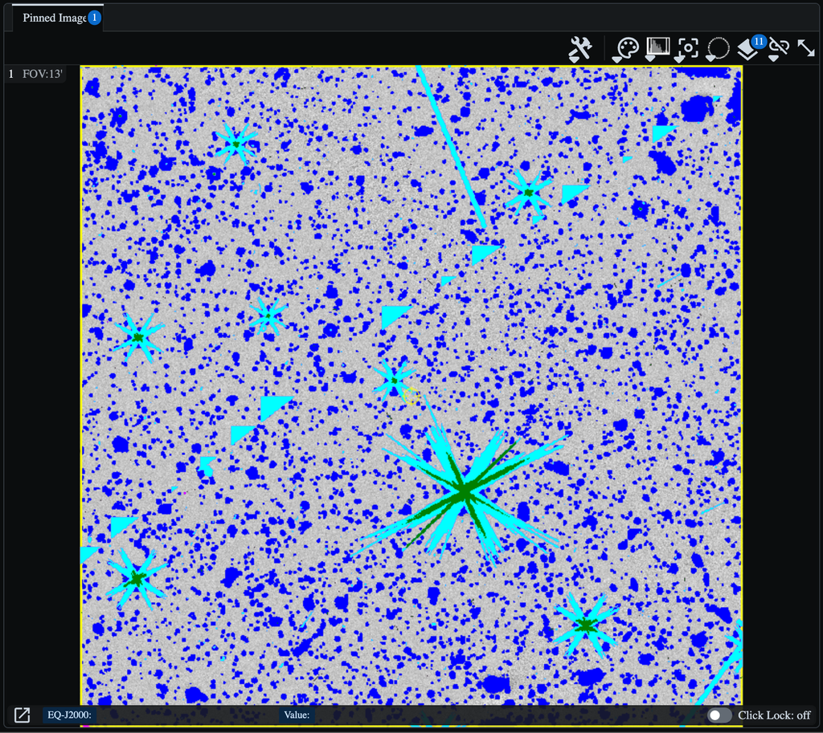

> **Figure 1:** The mask plane of the r-band `deep_coadd` image for tract 5063, patch 15. The colors correspond to an informative mask flag value (Section 3.3). A large fraction of the pixels have a color (have a nonzero mask value).

### 3.1. Image plane

Sky pixel data in units of nJy (nanojanskys).

The background has been subtracted so values can be negative.

Extract the `image` data from the `deep_coadd`, and convert it to an array.

```python
image = deep_coadd.image
image_array = image.array
```

Option to show the `image` and the `image_array`.

```python
# image
```

```python
# image_array
```

Print statistics on the `image_array`.

```python
print(image_array.min())
print(image_array.mean())
print(image_array.max())
```

```
-150.19159
3.5985272
48950.227
```

Display the `image` in Firefly frame 2.

```python
afw_display = afwDisplay.Display(frame=2)
afw_display.mtv(image)
```

Mouse-over display frame 2. The `image` plane contains less information than the full `CellCoadd`, but nonetheless displays coordinates in RA, Dec, as it does carry a WCS.

### 3.2. Variance plane

Uncertainty (noise) in the sky pixel data in units of nJy^2 (nanojanskys squared).

Values are always positive.

Extract the `variance` and `variance_array`.

```python
variance = deep_coadd.variance
variance_array = variance.array
```

Print statistics on the `variance_array`.

```python
print(variance_array.min())
print(variance_array.mean())
print(variance_array.max())
```

```
0.23627509
inf
inf
```

The mean and maximum values printed to the screen are `inf` (infinity). This is because masked pixels (e.g., the saturated pixels at the centers of bright stars) can have no data in the `deep_coadd`, which causes the variance for those pixels to be infinite.

Flag the pixels with `inf` values, count how many there are, and recalculate statistics with those pixels removed.

```python
inf_variance = (variance_array == np.inf)
print(f"Number of pixels with infinite variance: {np.sum(inf_variance)}")

print("\nStatistics without inf pixels:")
print(variance_array[~inf_variance].min())
print(variance_array[~inf_variance].mean())
print(variance_array[~inf_variance].max())
```

```
Number of pixels with infinite variance: 9

Statistics without inf pixels:
0.23627509
25.55358
6961.53
```

Display the `variance`. Note that the default auto-scaling of the image stretch will cause the image to look "blank." Change the stretch (to, for example, "Z Scale Linear Stretch") to see detail in the variance image.

```python
afw_display = afwDisplay.Display(frame=3)
afw_display.mtv(variance)
```

### 3.3. Mask plane

An integer bitmask of representative flag values that indicate processing status or issues, similar to the [SDSS bitmasks](https://www.sdss4.org/dr17/algorithms/bitmasks/).

Extract the `mask`.

```python
mask = deep_coadd.mask
mask_array = mask.array
```

Mask keys (names) are defined by the `mask` and interpreted as colors by `afw_display`.

Print the list of mask keys and their descriptions.

```python
print(mask.schema)
```

```
NO_DATA [0@0x1]: No data was available for this pixel.
INTERPOLATED [0@0x2]: Pixel value is the result of interpolating nearby good pixels.
COSMIC_RAY [0@0x4]: A cosmic ray affected this pixel on at least one input image (and was interpolated).
SATURATED [0@0x8]: More than 10% of the potential input visits had a saturated pixel at this location ('potential' because saturated pixel values are not actually propagated to the coadd). SATURATED always implies REJECTED, and is often a reason for NO_DATA.
DETECTION_EDGE [0@0x10]: Pixel was too close to the edge of the patch to be considered for detection, due to the finite size of the detection kernel.
CLIPPED [0@0x20]: Region was identified as a probable artifact when comparing multiple single-visit warps. CLIPPED always implies REJECTED.
REJECTED [0@0x40]: At least one input visit was left out of the coadd for this pixel due to masking. REJECTED always implies INEXACT_PSF.
DETECTED [0@0x80]: Pixel was part of a detected source.
INEXACT_PSF [1@0x1]: The set of visits contributing to this pixel differs from the set of visits contributing to the PSF model for its cell.
```

Display the mask in Firefly frame 4.

```python
afw_display = afwDisplay.Display(frame=4)
afw_display.mtv(mask)
```

The colors are different because the Firefly display interprets the pixel values as flux values (mouse-over and see).

Set the mask transparency to opaque to see the same colors as in frame 1.

```python
afw_display.setMaskTransparency(0)
```

Set all mask key names to transparent except the "DETECTED" mask bit.

```python
afw_display.setMaskTransparency(100)
afw_display.setMaskTransparency(0, 'DETECTED')
```

Option to print a list of the mask planes and the number of pixels with each mask plane set.

```python
# for plane in mask.schema:
#     print(plane.name, np.sum(mask.get(plane.name)))
```

### 3.4. Background

Coadds have a final round of background subtraction applied (in addition to the background subtraction that was already applied to each of the input visits). Extract the `backgrounds` dict and examine the contents.

```python
backgrounds = deep_coadd.backgrounds

for key in backgrounds.keys():
    print(key)
```

```
pretty
object
```

Print the description of each background type to the screen.

```python
bg_obj = deep_coadd.backgrounds['object']
bg_pretty = deep_coadd.backgrounds['pretty']

print("object:\n", bg_obj.description)
print('\n')
print("pretty:\n", bg_pretty.description)
```

```
object:
 Background subtracted from the image when generating the Object catalog. This intentionally oversubtracts the background to reduce blending and ensure scattered light is subtracted. Restoring this background does not restore all original backgrounds, as the coadd was built from background-subtracte…


pretty:
 An alternate background optimized for visually attractive RGB images. 'Subtracting' this background will generally *add* flux, correcting for most oversubtraction problems, but leaving in scattered light and some instrumental backgrounds in some cases. Because this background is fit to a difference…
```

Render the backgrounds as images and display them.

```python
bg_obj_image = bg_obj.field.render()
bg_pretty_image = bg_pretty.field.render()
```

```python
afw_display = afwDisplay.Display(frame=3)
afw_display.mtv(bg_obj_image)

afw_display = afwDisplay.Display(frame=4)
afw_display.mtv(bg_pretty_image)
```

Make a copy of the `deep_coadd`, then use the `apply_background` method to restore some of the background that is often oversubtracted by the default behavior. Display this "restored" `pretty_coadd` in frame 1.

```python
pretty_coadd = deep_coadd.copy()
pretty_coadd.apply_background('pretty')
```

```python
afw_display = afwDisplay.Display(frame=1)
afw_display.mtv(pretty_coadd)
```

Use the Image alignment drop-down in Firefly to lock the images by pixel origin, then examine various regions of the images to compare the `pretty_coadd` (now in frame 1) to the `deep_coadd` image (in frame 2) and the backgrounds in frames 3 and 4.

Clean up.

```python
del image, image_array, variance, variance_array, mask, mask_array, pretty_coadd
```

## 4. Image attributes

### 4.1. Cell-based coadds

#### 4.1.1. Input visits

Information about the input visits that contributed to the `deep_coadd`.

The `deep_coadd` images are made up of a grid of 22x22 150-pixel "cells", within which the PSF may be considered "edge-free" (meaning it was created in a way that avoids any discontinuities). The cells are created separately, then stitched together into a `deep_coadd`. Thus the set of inputs for each cell can be slightly different.

Get the provenance info about each cell and inspect it. Cells are identified by indices *i* and *j*.

```python
contrib = deep_coadd.provenance.contributions.to_pandas()
```

```python
contrib
```

|  | cell_i | cell_j | visit | detector | overlaps_center | overlap_fraction | unmasked_fraction | weight | psf_shape_xx | psf_shape_yy | psf_shape_xy | psf_shape_flag | instrument |
| --- | --- | --- | --- | --- | --- | --- | --- | --- | --- | --- | --- | --- | --- |
| 0 | 0 | 0 | 2025072800396 | 97 | True | 1.0 | 0.992044 | 0.004219 | 7.407177 | 5.427278 | -0.020960 | False | LSSTCam |
| 1 | 0 | 0 | 2025072800397 | 97 | True | 1.0 | 0.986889 | 0.004169 | 8.689157 | 6.845690 | -0.636649 | False | LSSTCam |
| 2 | 0 | 0 | 2025072800398 | 97 | True | 1.0 | 0.997067 | 0.004197 | 7.595631 | 6.659030 | -0.131480 | False | LSSTCam |
| 3 | 0 | 0 | 2025072800399 | 97 | True | 1.0 | 0.978044 | 0.004235 | 6.482252 | 6.736140 | -0.323755 | False | LSSTCam |
| 4 | 0 | 0 | 2025072800400 | 97 | True | 1.0 | 0.983867 | 0.004250 | 5.927198 | 5.833827 | -0.329723 | False | LSSTCam |
| ... | ... | ... | ... | ... | ... | ... | ... | ... | ... | ... | ... | ... | ... |
| 10382 | 21 | 21 | 2026010500066 | 94 | True | 1.0 | 1.000000 | 0.001420 | 3.044833 | 3.736348 | 0.369175 | False | LSSTCam |
| 10383 | 21 | 21 | 2026010500067 | 94 | True | 1.0 | 1.000000 | 0.001420 | 2.789960 | 3.681143 | 0.449140 | False | LSSTCam |
| 10384 | 21 | 21 | 2026010500069 | 94 | True | 1.0 | 1.000000 | 0.001409 | 2.926084 | 3.519976 | 0.265914 | False | LSSTCam |
| 10385 | 21 | 21 | 2026010500070 | 94 | True | 1.0 | 1.000000 | 0.001411 | 3.288111 | 3.596816 | 0.277896 | False | LSSTCam |
| 10386 | 21 | 21 | 2026010500071 | 91 | True | 1.0 | 1.000000 | 0.001398 | 3.399342 | 4.159896 | 0.539613 | False | LSSTCam |

10387 rows × 13 columns

Make a histogram of the number of inputs contributing to each cell. The `pandas` "groupby" function makes it easy to group combinations of *ij* indices.

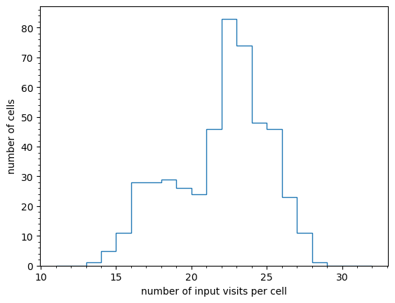

```python
plt.hist(contrib.groupby(['cell_i', 'cell_j']).count()['visit'], bins=np.arange(11, 33, 1.0),
         histtype='step')
plt.minorticks_on()
plt.xlabel('number of input visits per cell')
plt.ylabel('number of cells')
plt.show()
```

> **Figure 2:** Histogram showing the number of input visits contributing to each cell of the `CellCoadd`.

Get the list of input images that were combined to generate the `deep_coadd`. Note: this list contains all inputs that contributed anywhere in the patch.

Display the first 3 rows of the inputs table.

```python
inputs = deep_coadd.provenance.inputs
print(f"Number of visits contributing to coadd: {len(inputs)}")
inputs[:3]
```

```
Number of visits contributing to coadd: 98
```

*Table length=3*

| visit uint64 | detector uint16 | day_obs uint32 | polygon object |
| --- | --- | --- | --- |
| 2025072800396 | 93 | 20250728 | POLYGON ((18149.5 3789.35009765625, 18048.044921875 3895.27978515625, 18149.5 3992.398681640625, 18149.5 3789.35009765625)) |
| 2025072800396 | 94 | 20250728 | POLYGON ((18149.5 4170.5751953125, 17960.4140625 3988.98828125, 15884.8779296875 6149.5, 18149.5 6149.5, 18149.5 4170.5751953125)) |
| 2025072800396 | 96 | 20250728 | POLYGON ((16961.666015625 2849.5, 17888.99609375 3738.50341796875, 18149.5 3466.904052734375, 18149.5 2849.5, 16961.666015625 2849.5)) |

Make a spatial plot in tract *xy* coordinates, color-coding each cell based on the number of input visits that contributed to that cell's coadd.

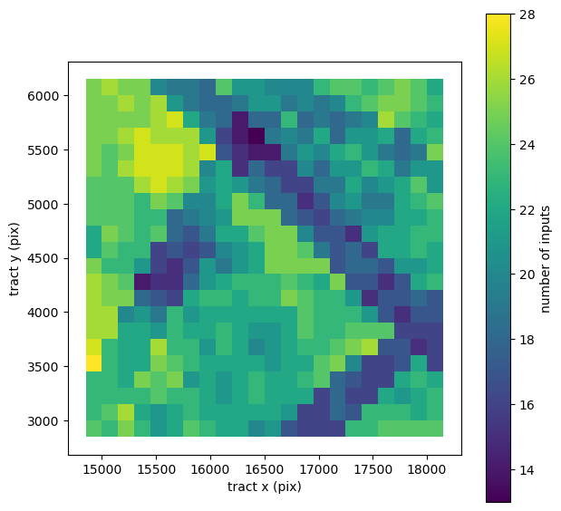

```python
unique_combinations = contrib[['cell_i', 'cell_j']].drop_duplicates()
ninputs = []
fig, ax = plt.subplots(figsize=(7, 7))

ninputs = contrib.groupby(['cell_i', 'cell_j']).size().to_numpy()

normal = plt.Normalize(np.min(ninputs), np.max(ninputs))
cmap = plt.cm.viridis
c = cmap(normal(ninputs))

patches = []

for i in range(len(unique_combinations)):
    cell_i = unique_combinations.iloc[i]['cell_i']
    cell_j = unique_combinations.iloc[i]['cell_j']
    pick_cell = (contrib['cell_i'] == cell_i) & (contrib['cell_j'] == cell_j)
    cell_bbox = deep_coadd.grid.bbox_of(CellIJ(cell_i, cell_j))
    patches.append(plt.Rectangle((cell_bbox.x.start, cell_bbox.y.start),
                                 150, 150, facecolor=c[i], fill=True))

col = PatchCollection(patches)
col.set(array=ninputs, cmap=cmap)

ax.add_collection(col)
ax.autoscale()
fig.colorbar(col, label='number of inputs')
ax.set_aspect('equal')

plt.xlabel('tract x (pix)')
plt.ylabel('tract y (pix)')
plt.show()
```

#### 4.1.2. Info about the cells

Explore the cell `grid` associated with the `deep_coadd` to learn how to access cell information.

First, extract the xy coordinate of the patch corner, `yx0`.

```python
xy0 = deep_coadd.yx0
```

Extract the grid indices of the cell corresponding to an *xy* coordinate, remembering to offset to tract *xy*.

```python
xcoord = 1914 + xy0.x
ycoord = 1200 + xy0.y
print(f"x: {xcoord}, y: {ycoord}")

cij = deep_coadd.grid.index_of(x=xcoord, y=ycoord)
print(cij)
```

```
x: 16764, y: 4050
CellIJ(i=8, j=12)
```

Extract the bounding box of the cell indices retrieved above.

```python
deep_coadd.grid.bbox_of(cij)
```

```
Box(y=Interval(start=4050, stop=4200), x=Interval(start=16650, stop=16800))
```

Print the grid size, then the dict of overall parameters defining the grid.

```python
deep_coadd.grid.grid_size
```

```
CellIJ(i=22, j=22)
```

```python
grid_dict = deep_coadd.grid.model_dump()

for key in grid_dict.keys():
    print(key, grid_dict[key], '\n')
```

```
bbox {'y': {'start': 2850, 'stop': 6150}, 'x': {'start': 14850, 'stop': 18150}}

cell_shape {'y': 150, 'x': 150}
```

```python
del inputs, grid_dict, xy0, xcoord, ycoord
```

### 4.2. World Coordinate System (WCS)

The reference system that maps pixel coordinate (x, y) to sky coordinate (RA, Dec).

#### 4.2.1. `sky_projection`

There are multiple encodings of the mapping between sky and pixel coordinates. The most precise version is the `sky_projection`. Retrieve the `sky_projection`.

```python
wcs = deep_coadd.sky_projection
```

Convert pixel coordinates to sky coordinates, and vice versa.

```python
coord = SkyCoord(ra=ra*u.deg, dec=dec*u.deg, frame='icrs')
xy = wcs.sky_to_pixel(coord)
coord
```

```
<SkyCoord (ICRS): (ra, dec) in deg
    (53.076, -28.11)>
```

```python
print(xy)
```

```
XY(x=15182.507513158846, y=4390.517978014746)
```

Always pass xy values in tract coordinates when converting from pixel to sky with `sky_projection`.

```python
xy2 = (15000, 4300)
print("x, y in tract coordinates: ", xy2[0], xy2[1])
print("Corner coordinates of patch: ", deep_coadd.yx0)
print("x, y in patch coordinates: ", xy2[0]-deep_coadd.yx0.x, xy2[1]-deep_coadd.yx0.y)
coord2 = wcs.pixel_to_sky(x=xy2[0], y=xy2[1])
```

```
x, y in tract coordinates:  15000 4300
Corner coordinates of patch:  YX(y=2850, x=14850)
x, y in patch coordinates:  150 1450
```

```python
print(coord2)
```

```
<SkyCoord (ICRS): (ra, dec) in deg
    (53.08749462, -28.11502872)>
```

#### 4.2.2. astropy_wcs

For users' convenience, an Astropy-compatible version of the WCS is also provided.

```python
wcs_astropy = deep_coadd.astropy_wcs
```

Convert the `SkyCoord` from the previous section ("coord2") to xy using the Astropy WCS, and compare the results to see that Astropy returns xy in local (patch) pixel values.

```python
print("Input xy: ", xy2)
xy2_astropy = wcs_astropy.world_to_pixel(coord2)
print("Output xy: ", xy2_astropy)
print("Output xy in tract coords: ",
      xy2_astropy.x+deep_coadd.yx0.x,
      xy2_astropy.y+deep_coadd.yx0.y)
```

```
Input xy:  (15000, 4300)
Output xy:  XY(x=149.99999999994907, y=1450.0000000000055)
Output xy in tract coords:  14999.999999999949 4300.0000000000055
```

Apply the Astropy `pixel_to_world` conversion, remembering to pass xy coordinates in local (patch) coordinates.

```python
coord2_astropy = wcs_astropy.pixel_to_world(xy2[0]-deep_coadd.yx0.x,
                                            xy2[1]-deep_coadd.yx0.y)
print(coord2_astropy)
```

```
<SkyCoord (ICRS): (ra, dec) in deg
    (53.08749462, -28.11502872)>
```

The RA, Dec coordinate agrees with the result from the previous section.

#### 4.2.3. fits_wcs

There is also a WCS in standard FITS format, provided as `fits_wcs`. For `deep_coadd` images this WCS is an exact representation of the LSST WCS for the image, but for other image types it may be an approximation to the WCS.

Read this WCS and print it to the screen.

```python
wcs_fits = deep_coadd.fits_wcs
```

```python
wcs_fits
```

```
WCS Keywords

Number of WCS axes: 2
CTYPE : 'RA---TAN' 'DEC--TAN'
CUNIT : 'deg' 'deg'
CRVAL : 53.08755760368661 -27.520661157024808
CRPIX : 150.0 12150.0
CD1_1 CD1_2  : -5.5555555555553004e-05 0.0
CD2_1 CD2_2  : 0.0 5.555555555555367e-05
NAXIS : 3300  3300
```

Print the object's associated methods to confirm that it also includes conversions between sky to pixel coordinates.

```python
dir(wcs_fits)
```

[output not shown]

[output cut: 76 more lines]

```
 'to_header',
 'to_header_string',
 'wcs',
 'wcs_pix2world',
 'wcs_world2pix',
 'world_axis_names',
 'world_axis_object_classes',
 'world_axis_object_components',
 'world_axis_physical_types',
 'world_axis_units',
 'world_n_dim',
 'world_to_array_index',
 'world_to_array_index_values',
 'world_to_pixel',
 'world_to_pixel_values']
```

```python
del xy, xy2, coord, coord2
```

### 4.3. Bounding box (corners)

The bounding box defines the extent (corners) of the image.

Get the bounding box.

```python
bbox = deep_coadd.bbox
```

Print the `deep_coadd` corners in pixels and sky coordinates.

```python
bbox.min.x
```

```
14850
```

```python
corners = ((bbox.min.x, bbox.min.y),
           (bbox.min.x, bbox.max.y),
           (bbox.max.x, bbox.max.y),
           (bbox.max.x, bbox.min.y))
for corner in corners:
    print("corner (x, y): ", corner, '\n', wcs.pixel_to_sky(x=corner[0], y=corner[1]))
```

```
corner (x, y):  (14850, 2850)
 <SkyCoord (ICRS): (ra, dec) in deg
    (53.09694922, -28.19557406)>
corner (x, y):  (14850, 6149)
 <SkyCoord (ICRS): (ra, dec) in deg
    (53.09693349, -28.01231544)>
corner (x, y):  (18149, 6149)
 <SkyCoord (ICRS): (ra, dec) in deg
    (52.88934327, -28.01217359)>
corner (x, y):  (18149, 2850)
 <SkyCoord (ICRS): (ra, dec) in deg
    (52.88901088, -28.19543113)>
```

Check if pixel values are within the bounding box.

```python
assert bbox.contains(x=100, y=100) is False
print(bbox.contains(x=100, y=100))
assert bbox.contains(x=16000, y=4000) is True
print(bbox.contains(x=16000, y=4000))
```

```
False
True
```

Check if sky coordinates are within the bounding box.

```python
coord = SkyCoord(ra=63.0*u.deg, dec=-38.0*u.deg, frame='icrs')
coord2 = SkyCoord(ra=53.0*u.deg, dec=-28.1*u.deg, frame='icrs')
xy = wcs.sky_to_pixel(coord)
xy2 = wcs.sky_to_pixel(coord2)
print(bbox.contains(x=xy[0], y=xy[1]))
print(bbox.contains(x=xy2[0], y=xy2[1]))
```

```
False
True
```

Clean up.

```python
del corners, coord, coord2, xy
```

### 4.4. Point spread function (PSF)

The PSF is the empirical estimate of the shape of a point source as a function of position in the image. The PSF encapsulates all of the atmospheric and optical effects that blur point sources into their measured shapes.

Get the PSF.

```python
psf = deep_coadd.psf
```

At pixel coordinates x, y = 16000, 4000, compute the PSF and display it in frame 5.

```python
xy = (16000, 4000)
psf_image = psf.compute_kernel_image(x=xy[0], y=xy[1])
afw_display = afwDisplay.Display(frame=5)
afw_display.mtv(psf_image)
```

Clean up.

```python
del psf, xy, psf_image
```

## 5. Detected objects

In general the TAP service is the recommended access mechanism for catalog data.

However, in the case where *all* the objects (or sources, for `visit_images`) detected in a given image are desired, the Butler offers a quick way to retrieve them.

Get the tract and patch for the `deep_coadd`.

```python
ref = dataset_refs[0]
dataId = ref.dataId
use_tract = dataId.get('tract')
use_patch = dataId.get('patch')
print(use_tract, use_patch)
```

```
5063 15
```

Show that the only dimension for the `object` dataset type is tract.

```python
butler.registry.queryDatasetTypes('object')
```

```
[DatasetType('object', {skymap, tract}, ArrowAstropy)]
```

Since a `butler.get` call on the `object` table will return all of the objects in a *tract*, not the single patch of the `deep_coadd`, return only a select few of the >1000 columns and include column `patch`.

```python
use_columns = ['objectId', 'patch',
               'coord_ra', 'coord_dec']
```

Retrive the `object` table as `objects`.

```python
objects = butler.get('object', tract=use_tract, skymap='lsst_cells_v2',
                     parameters={'columns': use_columns})
```

Print the number of sources in the detector for this `deep_coadd` (for its `patch`).

```python
tx = np.where(objects['patch'] == use_patch)[0]
print(len(tx))
```

```
9058
```

Option to show the table.

```python
# objects[tx]
```

Redisplay the `deep_coadd` in frame 1 with no mask.

```python
afw_display = afwDisplay.Display(frame=1)
afw_display.mtv(deep_coadd)
afw_display.setMaskTransparency(100)
```

Overplot sources in the `deep_coadd` with orange circles.

```python
sc_patch = SkyCoord(ra=objects['coord_ra']*u.deg,
                    dec=objects['coord_dec']*u.deg,
                    frame='icrs')

with afw_display.Buffering():
    for i in tx:
        xy_tmp = wcs.sky_to_pixel(sc_patch[i])
        afw_display.dot('o',
                        xy_tmp.x,
                        xy_tmp.y,
                        size=20, ctype='orange')
```

Notice that no objects near the edges are marked with an orange circle; they are listed as belonging to the adjacent patch.

Clean up.

```python
del ref, dataId, use_tract, use_patch, use_columns, objects, tx
del dataset_refs, deep_coadd
```